# Project 1- App Rating

```python
import pandas as pd
import numpy as np
import matplotlib.pyplot as plt, seaborn as sns
%matplotlib inline

import warnings
warnings.simplefilter(action='ignore', category=FutureWarning)
```

## Ans 1- Load the data file using pandas.

```python
data= pd.read_csv('googleplaystore.csv')
```

```python
data.head()
```

|  | App | Category | Rating | Reviews | Size | Installs | Type | Price | Content Rating | Genres | Last Updated | Current Ver | Android Ver |
| --- | --- | --- | --- | --- | --- | --- | --- | --- | --- | --- | --- | --- | --- |
| 0 | Photo Editor & Candy Camera & Grid & ScrapBook | ART_AND_DESIGN | 4.1 | 159 | 19M | 10,000+ | Free | 0 | Everyone | Art & Design | January 7, 2018 | 1.0.0 | 4.0.3 and up |
| 1 | Coloring book moana | ART_AND_DESIGN | 3.9 | 967 | 14M | 500,000+ | Free | 0 | Everyone | Art & Design;Pretend Play | January 15, 2018 | 2.0.0 | 4.0.3 and up |
| 2 | U Launcher Lite – FREE Live Cool Themes, Hide ... | ART_AND_DESIGN | 4.7 | 87510 | 8.7M | 5,000,000+ | Free | 0 | Everyone | Art & Design | August 1, 2018 | 1.2.4 | 4.0.3 and up |
| 3 | Sketch - Draw & Paint | ART_AND_DESIGN | 4.5 | 215644 | 25M | 50,000,000+ | Free | 0 | Teen | Art & Design | June 8, 2018 | Varies with device | 4.2 and up |
| 4 | Pixel Draw - Number Art Coloring Book | ART_AND_DESIGN | 4.3 | 967 | 2.8M | 100,000+ | Free | 0 | Everyone | Art & Design;Creativity | June 20, 2018 | 1.1 | 4.4 and up |

```python
data.info()
```

```
<class 'pandas.core.frame.DataFrame'>
RangeIndex: 10841 entries, 0 to 10840
Data columns (total 13 columns):
 #   Column          Non-Null Count  Dtype
---  ------          --------------  -----
 0   App             10841 non-null  object
 1   Category        10841 non-null  object
 2   Rating          9367 non-null   float64
 3   Reviews         10841 non-null  object
 4   Size            10841 non-null  object
 5   Installs        10841 non-null  object
 6   Type            10840 non-null  object
 7   Price           10841 non-null  object
 8   Content Rating  10840 non-null  object
 9   Genres          10841 non-null  object
 10  Last Updated    10841 non-null  object
 11  Current Ver     10833 non-null  object
 12  Android Ver     10838 non-null  object
dtypes: float64(1), object(12)
memory usage: 1.1+ MB
```

## Ans 2- Check for null values in the data. Get the number of null values for each column.

Dropping the records with null ratings

- this is done because ratings is our target variable

```python
data.isnull().sum(axis=0)
```

```
App                  0
Category             0
Rating            1474
Reviews              0
Size                 0
Installs             0
Type                 1
Price                0
Content Rating       1
Genres               0
Last Updated         0
Current Ver          8
Android Ver          3
dtype: int64
```

## Ans 3- Drop records with nulls in any of the columns.

```python
data.dropna(how ='any', inplace = True)
```

```python
data.isnull().sum(axis=0)
```

```
App               0
Category          0
Rating            0
Reviews           0
Size              0
Installs          0
Type              0
Price             0
Content Rating    0
Genres            0
Last Updated      0
Current Ver       0
Android Ver       0
dtype: int64
```

Confirming that the null records have been dropped

#### Change variable to correct types

```python
data.dtypes
```

```
App                object
Category           object
Rating            float64
Reviews            object
Size               object
Installs           object
Type               object
Price              object
Content Rating     object
Genres             object
Last Updated       object
Current Ver        object
Android Ver        object
dtype: object
```

```python
data.head()
```

|  | App | Category | Rating | Reviews | Size | Installs | Type | Price | Content Rating | Genres | Last Updated | Current Ver | Android Ver |
| --- | --- | --- | --- | --- | --- | --- | --- | --- | --- | --- | --- | --- | --- |
| 0 | Photo Editor & Candy Camera & Grid & ScrapBook | ART_AND_DESIGN | 4.1 | 159 | 19M | 10,000+ | Free | 0 | Everyone | Art & Design | January 7, 2018 | 1.0.0 | 4.0.3 and up |
| 1 | Coloring book moana | ART_AND_DESIGN | 3.9 | 967 | 14M | 500,000+ | Free | 0 | Everyone | Art & Design;Pretend Play | January 15, 2018 | 2.0.0 | 4.0.3 and up |
| 2 | U Launcher Lite – FREE Live Cool Themes, Hide ... | ART_AND_DESIGN | 4.7 | 87510 | 8.7M | 5,000,000+ | Free | 0 | Everyone | Art & Design | August 1, 2018 | 1.2.4 | 4.0.3 and up |
| 3 | Sketch - Draw & Paint | ART_AND_DESIGN | 4.5 | 215644 | 25M | 50,000,000+ | Free | 0 | Teen | Art & Design | June 8, 2018 | Varies with device | 4.2 and up |
| 4 | Pixel Draw - Number Art Coloring Book | ART_AND_DESIGN | 4.3 | 967 | 2.8M | 100,000+ | Free | 0 | Everyone | Art & Design;Creativity | June 20, 2018 | 1.1 | 4.4 and up |

## 4. Variables seem to have incorrect type and inconsistent formatting. You need to fix them:

1. Size column has sizes in Kb as well as Mb. To analyze, you’ll need to convert these to numeric. a. Extract the numeric value from the column b. Multiply the value by 1,000, if size is mentioned in Mb
2. Reviews is a numeric field that is loaded as a string field. Convert it to numeric (int/float).
3. Installs field is currently stored as string and has values like 1,000,000+. a. Treat 1,000,000+ as 1,000,000 b. remove ‘+’, ‘,’ from the field, convert it to integer
4. Price field is a string and has $ symbol. Remove ‘$’ sign, and convert it to numeric.

#### 4.4 Price column needs to be cleaned

```python
data.Price.value_counts()[:5]
```

```
0        8715
$2.99     114
$0.99     106
$4.99      70
$1.99      59
Name: Price, dtype: int64
```

```python
display (data['Price'][:5])
data['Price'] = data.Price.map(lambda x: 0 if x == '0' else float(x[1:]))
display (data['Price'][:5])
```

```
0    0
1    0
2    0
3    0
4    0
Name: Price, dtype: object
```

```
0    0.0
1    0.0
2    0.0
3    0.0
4    0.0
Name: Price, dtype: float64
```

```python
##data['Price'] = data.Price.map(lambda x: 0 if x == '0' else float(x[1:]))
```

#### 4.2 Converting reviews to numeric

```python
data.Reviews = data.Reviews.astype("int32")
```

```python
data.Reviews.describe()
```

```
count    9.360000e+03
mean     5.143767e+05
std      3.145023e+06
min      1.000000e+00
25%      1.867500e+02
50%      5.955000e+03
75%      8.162750e+04
max      7.815831e+07
Name: Reviews, dtype: float64
```

#### 4.3 Now, handling the installs column

```python
data.Installs.value_counts()
```

```
1,000,000+        1576
10,000,000+       1252
100,000+          1150
10,000+           1009
5,000,000+         752
1,000+             712
500,000+           537
50,000+            466
5,000+             431
100,000,000+       409
100+               309
50,000,000+        289
500+               201
500,000,000+        72
10+                 69
1,000,000,000+      58
50+                 56
5+                   9
1+                   3
Name: Installs, dtype: int64
```

#### We'll need to remove the commas and the plus signs`

Defining function for the same

```python
def clean_installs(val):
    return int(val.replace(",","").replace("+",""))
```

```python
data.Installs = data.Installs.map(clean_installs)
```

```python
data.Installs.describe()
```

```
count    9.360000e+03
mean     1.790875e+07
std      9.126637e+07
min      1.000000e+00
25%      1.000000e+04
50%      5.000000e+05
75%      5.000000e+06
max      1.000000e+09
Name: Installs, dtype: float64
```

#### 4.1 Handling the app size field

```python
def change_size(size):
    if 'M' in size:
        x = size[:-1]
        x = float(x)*1000
        return(x)
    elif 'k' == size[-1:]:
        x = size[:-1]
        x = float(x)
        return(x)
    else:
        return None
```

```python
change_size("19M")
```

```
19000.0
```

```python
data["Size"] = data["Size"].map(change_size)
```

```python
data.Size.describe()
```

```
count      7723.000000
mean      22970.456105
std       23449.628935
min           8.500000
25%        5300.000000
50%       14000.000000
75%       33000.000000
max      100000.000000
Name: Size, dtype: float64
```

```python
data["Size"].isnull().sum()
```

```
1637
```

```python
#filling Size which had NA
data.Size.fillna(method = 'ffill', inplace = True)
```

```python
data.dtypes
```

```
App                object
Category           object
Rating            float64
Reviews             int32
Size              float64
Installs            int64
Type               object
Price             float64
Content Rating     object
Genres             object
Last Updated       object
Current Ver        object
Android Ver        object
dtype: object
```

## 5.A Some sanity checks

1. Average rating should be between 1 and 5 as only these values are allowed on the play store. Drop the rows that have a value outside this range.
2. Reviews should not be more than installs as only those who installed can review the app. If there are any such records, drop them.
3. For free apps (type = “Free”), the price should not be >0. Drop any such rows.

#### 5.1 Avg. rating should be between 1 and 5, as only these values are allowed on the play store. Drop any rows that have a value outside this range.

```python
data.Rating.describe()
```

```
count    9360.000000
mean        4.191838
std         0.515263
min         1.000000
25%         4.000000
50%         4.300000
75%         4.500000
max         5.000000
Name: Rating, dtype: float64
```

Min is 1 and max is 5. Looks good.

#### 5.2. Reviews should not be more than installs as only those who installed can review the app.

Checking if reviews are more than installs. Counting total rows like this.

```python
len(data[data.Reviews > data.Installs])
```

```
7
```

```python
data[data.Reviews > data.Installs]
```

|  | App | Category | Rating | Reviews | Size | Installs | Type | Price | Content Rating | Genres | Last Updated | Current Ver | Android Ver |
| --- | --- | --- | --- | --- | --- | --- | --- | --- | --- | --- | --- | --- | --- |
| 2454 | KBA-EZ Health Guide | MEDICAL | 5.0 | 4 | 25000.0 | 1 | Free | 0.00 | Everyone | Medical | August 2, 2018 | 1.0.72 | 4.0.3 and up |
| 4663 | Alarmy (Sleep If U Can) - Pro | LIFESTYLE | 4.8 | 10249 | 30000.0 | 10000 | Paid | 2.49 | Everyone | Lifestyle | July 30, 2018 | Varies with device | Varies with device |
| 5917 | Ra Ga Ba | GAME | 5.0 | 2 | 20000.0 | 1 | Paid | 1.49 | Everyone | Arcade | February 8, 2017 | 1.0.4 | 2.3 and up |
| 6700 | Brick Breaker BR | GAME | 5.0 | 7 | 19000.0 | 5 | Free | 0.00 | Everyone | Arcade | July 23, 2018 | 1.0 | 4.1 and up |
| 7402 | Trovami se ci riesci | GAME | 5.0 | 11 | 6100.0 | 10 | Free | 0.00 | Everyone | Arcade | March 11, 2017 | 0.1 | 2.3 and up |
| 8591 | DN Blog | SOCIAL | 5.0 | 20 | 4200.0 | 10 | Free | 0.00 | Teen | Social | July 23, 2018 | 1.0 | 4.0 and up |
| 10697 | Mu.F.O. | GAME | 5.0 | 2 | 16000.0 | 1 | Paid | 0.99 | Everyone | Arcade | March 3, 2017 | 1.0 | 2.3 and up |

```python
data = data[data.Reviews <= data.Installs].copy()
```

```python
data.shape
```

```
(9353, 13)
```

### 5.3 For free apps (type = “Free”), the price should not be > 0. Drop any such rows.

```python
len(data[(data.Type == "Free") & (data.Price>0)])
```

```
0
```

## 5.B. Performing univariate analysis:

#### Box plot for price

o Are there any outliers? Think about the price of usual apps on Play Store.

#### Remark : As can be seen below histogram, mostly app hav price range between 0-50. However, there are some app which were prices more then 300. Which is visible in both the below plots. Hence, there are outliers.

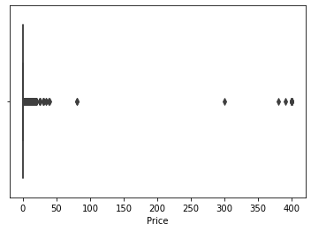

```python
sns.boxplot(data.Price)
```

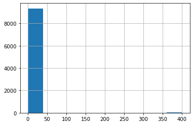

```python
data['Price'].hist()
```

#### Box plot for Reviews

o Are there any apps with very high number of reviews? Do the values seem right?

#### Remark : Yes, there are many apps with very high number of reviews. But, as per data Reviews are less the numbe rof app instal, hence value seems right.

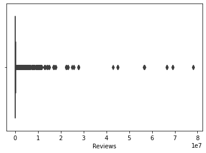

```python
sns.boxplot(data.Reviews)
```

```python
max(data['Reviews'])
```

```
78158306
```

```python
data[data['Reviews'] > data['Installs']]
```

|  | App | Category | Rating | Reviews | Size | Installs | Type | Price | Content Rating | Genres | Last Updated | Current Ver | Android Ver |
| --- | --- | --- | --- | --- | --- | --- | --- | --- | --- | --- | --- | --- | --- |

```python
data[data['Reviews'] >= 50000]
```

|  | App | Category | Rating | Reviews | Size | Installs | Type | Price | Content Rating | Genres | Last Updated | Current Ver | Android Ver |
| --- | --- | --- | --- | --- | --- | --- | --- | --- | --- | --- | --- | --- | --- |
| 2 | U Launcher Lite – FREE Live Cool Themes, Hide ... | ART_AND_DESIGN | 4.7 | 87510 | 8700.0 | 5000000 | Free | 0.0 | Everyone | Art & Design | August 1, 2018 | 1.2.4 | 4.0.3 and up |
| 3 | Sketch - Draw & Paint | ART_AND_DESIGN | 4.5 | 215644 | 25000.0 | 50000000 | Free | 0.0 | Teen | Art & Design | June 8, 2018 | Varies with device | 4.2 and up |
| 18 | FlipaClip - Cartoon animation | ART_AND_DESIGN | 4.3 | 194216 | 39000.0 | 5000000 | Free | 0.0 | Everyone | Art & Design | August 3, 2018 | 2.2.5 | 4.0.3 and up |
| 19 | ibis Paint X | ART_AND_DESIGN | 4.6 | 224399 | 31000.0 | 10000000 | Free | 0.0 | Everyone | Art & Design | July 30, 2018 | 5.5.4 | 4.1 and up |
| 42 | Textgram - write on photos | ART_AND_DESIGN | 4.4 | 295221 | 10000.0 | 10000000 | Free | 0.0 | Everyone | Art & Design | July 30, 2018 | Varies with device | Varies with device |
| ... | ... | ... | ... | ... | ... | ... | ... | ... | ... | ... | ... | ... | ... |
| 10796 | Inf VPN - Global Proxy & Unlimited Free WIFI VPN | TOOLS | 4.7 | 61445 | 7800.0 | 1000000 | Free | 0.0 | Everyone | Tools | July 26, 2018 | 1.9.734 | 4.1 and up |
| 10803 | Fatal Raid - No.1 Mobile FPS | GAME | 4.3 | 56496 | 81000.0 | 1000000 | Free | 0.0 | Teen | Action | August 7, 2018 | 1.5.447 | 4.0 and up |
| 10809 | Castle Clash: RPG War and Strategy FR | FAMILY | 4.7 | 376223 | 24000.0 | 1000000 | Free | 0.0 | Everyone | Strategy | July 18, 2018 | 1.4.2 | 4.1 and up |
| 10826 | Frim: get new friends on local chat rooms | SOCIAL | 4.0 | 88486 | 8600.0 | 5000000 | Free | 0.0 | Mature 17+ | Social | March 23, 2018 | Varies with device | Varies with device |
| 10840 | iHoroscope - 2018 Daily Horoscope & Astrology | LIFESTYLE | 4.5 | 398307 | 19000.0 | 10000000 | Free | 0.0 | Everyone | Lifestyle | July 25, 2018 | Varies with device | Varies with device |

2782 rows × 13 columns

#### Histogram for Rating

o How are the ratings distributed? Is it more toward higher ratings?

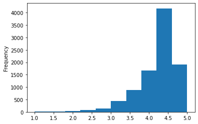

```python
data.Rating.plot.hist()
```

```python
data[(data['Rating']>4.2) & (data['Rating']>4.7) ]
```

|  | App | Category | Rating | Reviews | Size | Installs | Type | Price | Content Rating | Genres | Last Updated | Current Ver | Android Ver |
| --- | --- | --- | --- | --- | --- | --- | --- | --- | --- | --- | --- | --- | --- |
| 25 | Harley Quinn wallpapers HD | ART_AND_DESIGN | 4.8 | 192 | 6000.0 | 10000 | Free | 0.0 | Everyone | Art & Design | April 25, 2018 | 1.5 | 3.0 and up |
| 55 | Tickets SDA 2018 and Exam from the State Traff... | AUTO_AND_VEHICLES | 4.9 | 10479 | 33000.0 | 100000 | Free | 0.0 | Everyone | Auto & Vehicles | July 18, 2018 | 1.7.1 | 4.0 and up |
| 61 | CDL Practice Test 2018 Edition | AUTO_AND_VEHICLES | 4.9 | 7774 | 17000.0 | 100000 | Free | 0.0 | Everyone | Auto & Vehicles | July 3, 2018 | 1.7 | 4.2 and up |
| 64 | DMV Permit Practice Test 2018 Edition | AUTO_AND_VEHICLES | 4.9 | 6090 | 27000.0 | 100000 | Free | 0.0 | Everyone | Auto & Vehicles | July 3, 2018 | 1.7 | 4.2 and up |
| 70 | Fines of the State Traffic Safety Inspectorate... | AUTO_AND_VEHICLES | 4.8 | 116986 | 35000.0 | 5000000 | Free | 0.0 | Everyone | Auto & Vehicles | August 2, 2018 | 1.9.7 | 4.0.3 and up |
| ... | ... | ... | ... | ... | ... | ... | ... | ... | ... | ... | ... | ... | ... |
| 10801 | Fr Ignacio Outreach | FAMILY | 4.9 | 52 | 19000.0 | 1000 | Free | 0.0 | Everyone | Education | January 19, 2018 | 1.0 | 4.4 and up |
| 10810 | Fr Lupupa Sermons | BUSINESS | 4.8 | 19 | 21000.0 | 100 | Free | 0.0 | Everyone | Business | June 12, 2018 | 1.0 | 4.4 and up |
| 10820 | Fr. Daoud Lamei | FAMILY | 5.0 | 22 | 8600.0 | 1000 | Free | 0.0 | Teen | Education | June 27, 2018 | 3.8.0 | 4.1 and up |
| 10833 | Chemin (fr) | BOOKS_AND_REFERENCE | 4.8 | 44 | 619.0 | 1000 | Free | 0.0 | Everyone | Books & Reference | March 23, 2014 | 0.8 | 2.2 and up |
| 10837 | Fr. Mike Schmitz Audio Teachings | FAMILY | 5.0 | 4 | 3600.0 | 100 | Free | 0.0 | Everyone | Education | July 6, 2018 | 1.0 | 4.1 and up |

588 rows × 13 columns

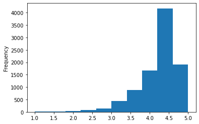

```python
data.Rating.plot.hist()
```

## 6. Outlier treatment:

1. Price: From the box plot, it seems like there are some apps with very high price. A price of $200 for an application on the Play Store is very high and suspicious! a. Check out the records with very high price

   ```
   i.  Is 200 indeed a high price?
   ```

   b. Drop these as most seem to be junk apps
2. Reviews: Very few apps have very high number of reviews. These are all star apps that don’t help with the analysis and, in fact, will skew it. Drop records having more than 2 million reviews.
3. Installs: There seems to be some outliers in this field too. Apps having very high number of installs should be dropped from the analysis.

   ```
   a.  Find out the different percentiles – 10, 25, 50, 70, 90, 95, 99
   b.  Decide a threshold as cutoff for outlier and drop records having values more than that
   ```

#### 6.1. Price: From the box plot, it seems like there are some apps with very high price. A price of $200 for an application on the Play Store is very high and suspicious!

```
a.  Check out the records with very high price
    i.  Is 200 indeed a high price?
b.  Drop these as most seem to be junk apps
```

```python
len(data[data.Price > 200])
```

```
15
```

```python
data.columns.tolist()
```

```
['App',
 'Category',
 'Rating',
 'Reviews',
 'Size',
 'Installs',
 'Type',
 'Price',
 'Content Rating',
 'Genres',
 'Last Updated',
 'Current Ver',
 'Android Ver']
```

```python
data[data.Price > 200]
```

|  | App | Category | Rating | Reviews | Size | Installs | Type | Price | Content Rating | Genres | Last Updated | Current Ver | Android Ver |
| --- | --- | --- | --- | --- | --- | --- | --- | --- | --- | --- | --- | --- | --- |
| 4197 | most expensive app (H) | FAMILY | 4.3 | 6 | 1500.0 | 100 | Paid | 399.99 | Everyone | Entertainment | July 16, 2018 | 1.0 | 7.0 and up |
| 4362 | 💎 I'm rich | LIFESTYLE | 3.8 | 718 | 26000.0 | 10000 | Paid | 399.99 | Everyone | Lifestyle | March 11, 2018 | 1.0.0 | 4.4 and up |
| 4367 | I'm Rich - Trump Edition | LIFESTYLE | 3.6 | 275 | 7300.0 | 10000 | Paid | 400.00 | Everyone | Lifestyle | May 3, 2018 | 1.0.1 | 4.1 and up |
| 5351 | I am rich | LIFESTYLE | 3.8 | 3547 | 1800.0 | 100000 | Paid | 399.99 | Everyone | Lifestyle | January 12, 2018 | 2.0 | 4.0.3 and up |
| 5354 | I am Rich Plus | FAMILY | 4.0 | 856 | 8700.0 | 10000 | Paid | 399.99 | Everyone | Entertainment | May 19, 2018 | 3.0 | 4.4 and up |
| 5355 | I am rich VIP | LIFESTYLE | 3.8 | 411 | 2600.0 | 10000 | Paid | 299.99 | Everyone | Lifestyle | July 21, 2018 | 1.1.1 | 4.3 and up |
| 5356 | I Am Rich Premium | FINANCE | 4.1 | 1867 | 4700.0 | 50000 | Paid | 399.99 | Everyone | Finance | November 12, 2017 | 1.6 | 4.0 and up |
| 5357 | I am extremely Rich | LIFESTYLE | 2.9 | 41 | 2900.0 | 1000 | Paid | 379.99 | Everyone | Lifestyle | July 1, 2018 | 1.0 | 4.0 and up |
| 5358 | I am Rich! | FINANCE | 3.8 | 93 | 22000.0 | 1000 | Paid | 399.99 | Everyone | Finance | December 11, 2017 | 1.0 | 4.1 and up |
| 5359 | I am rich(premium) | FINANCE | 3.5 | 472 | 965.0 | 5000 | Paid | 399.99 | Everyone | Finance | May 1, 2017 | 3.4 | 4.4 and up |
| 5362 | I Am Rich Pro | FAMILY | 4.4 | 201 | 2700.0 | 5000 | Paid | 399.99 | Everyone | Entertainment | May 30, 2017 | 1.54 | 1.6 and up |
| 5364 | I am rich (Most expensive app) | FINANCE | 4.1 | 129 | 2700.0 | 1000 | Paid | 399.99 | Teen | Finance | December 6, 2017 | 2 | 4.0.3 and up |
| 5366 | I Am Rich | FAMILY | 3.6 | 217 | 4900.0 | 10000 | Paid | 389.99 | Everyone | Entertainment | June 22, 2018 | 1.5 | 4.2 and up |
| 5369 | I am Rich | FINANCE | 4.3 | 180 | 3800.0 | 5000 | Paid | 399.99 | Everyone | Finance | March 22, 2018 | 1.0 | 4.2 and up |
| 5373 | I AM RICH PRO PLUS | FINANCE | 4.0 | 36 | 41000.0 | 1000 | Paid | 399.99 | Everyone | Finance | June 25, 2018 | 1.0.2 | 4.1 and up |

```python
data = data[data.Price < 200]
```

#### 6.2 Reviews: Very few apps have very high number of reviews. These are all star apps that don’t help with the analysis and, in fact, will skew it. Drop records having more than 2 million reviews.

```python
data = data[data.Reviews <= 2000000]
data.shape
```

```
(8885, 13)
```

#### 6.3 Installs: There seems to be some outliers in this field too. Apps having very high number of installs should be dropped from the analysis.

```
    a.  Find out the different percentiles – 10, 25, 50, 70, 90, 95, 99
    b.  Decide a threshold as cutoff for outlier and drop records having values more than that
```

```python
data.Installs.quantile([0.1, 0.25, 0.5, 0.70, 0.9, 0.95, 0.99])
```

```
0.10         1000.0
0.25        10000.0
0.50       500000.0
0.70      1000000.0
0.90     10000000.0
0.95     10000000.0
0.99    100000000.0
Name: Installs, dtype: float64
```

```python
len(data[data.Installs >= 100000000])
```

```
142
```

## 7. Bivariate analysis: Let’s look at how the available predictors relate to the variable of interest, i.e., our target variable rating. Make scatter plots (for numeric features) and box plots (for character features) to assess the relations between rating and the other features.

```
1.  Make scatter plot/joinplot for Rating vs. Price
    a.  What pattern do you observe? Does rating increase with price?
2.  Make scatter plot/joinplot for Rating vs. Size
    a.  Are heavier apps rated better?
3.  Make scatter plot/joinplot for Rating vs. Reviews
    a.  Does more review mean a better rating always?
4.  Make boxplot for Rating vs. Content Rating
    a.  Is there any difference in the ratings? Are some types liked better?
5.  Make boxplot for Ratings vs. Category
    a.  Which genre has the best ratings?
```

### For each of the plots above, note down your observation.

#### 7.1. Make scatter plot/joinplot for Rating vs Price

```
a.  What pattern do you observe? Does rating increase with price?
```

#### Remark: While there is not a very clean pattern, it does look that the higher priced apps have better rating. Although, there are not a lot of apps which are high priced, but the pattern is apparent.¶

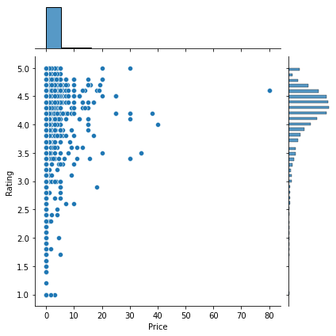

```python
sns.jointplot(data.Price, data.Rating);
```

#### 7.2 Make scatter plot/joinplot for Rating vs Size

```
 a. Are heavier apps rated better?
```

#### Remark: not a very clean pattern, but it does look like heavier apps are better rated.

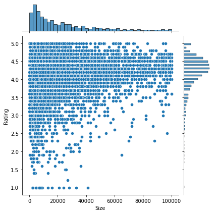

```python
sns.jointplot(data.Size, data.Rating);
```

#### 7.3 Make scatter plot/joinplot for Rating vs Reviews

```
a.  Does more review mean a better rating always?
```

#### Remark: There are fewer low rated apps among the popular ones (maybe poor ones won’t get so popular), after a certain point, the rating does not depend on the popularity.

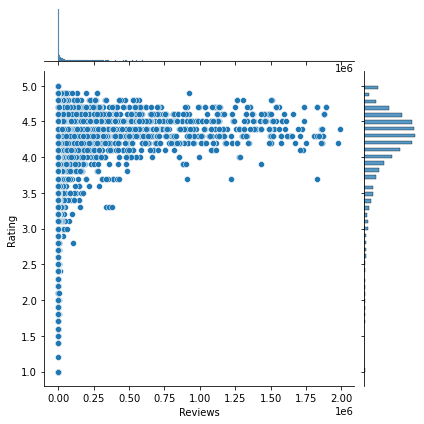

```python
sns.jointplot(data.Reviews, data.Rating);
```

#### 7.4 Make boxplot for Rating vs Content Rating

```
a.  Is there any difference in the ratings? Are some types liked better?
```

#### Remark: While the median rating for most others is similar, the rating for “Adults Only 18+” is the highest.

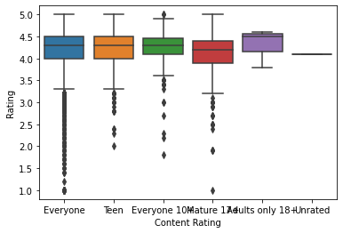

```python
sns.boxplot(data['Content Rating'], data['Rating']);
```

#### 7.5 Make boxplot for Ratings vs. Category

```
a.  Which genre has the best ratings?
```

#### Remark: Apps around Health & Fitness, Books and Reference, Events seem to have the highest median ratings.

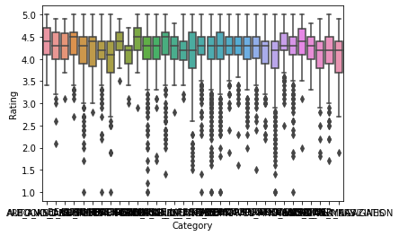

```python
sns.boxplot(data.Category, data.Rating);
```

## 8 Data preprocessing

For the steps below, create a copy of the dataframe to make all the edits. Name it inp1.

1. Reviews and Install have some values that are still relatively very high. Before building a linear regression model, you need to reduce the skew. Apply log transformation (np.log1p) to Reviews and Installs.
2. Drop columns App, Last Updated, Current Ver, and Android Ver. These variables are not useful for our task.
3. Get dummy columns for Category, Genres, and Content Rating. This needs to be done as the models do not understand categorical data, and all data should be numeric. Dummy encoding is one way to convert character fields to numeric. Name of dataframe should be inp2.

```python
inp1=data
```

```python
inp1
```

|  | App | Category | Rating | Reviews | Size | Installs | Type | Price | Content Rating | Genres | Last Updated | Current Ver | Android Ver |
| --- | --- | --- | --- | --- | --- | --- | --- | --- | --- | --- | --- | --- | --- |
| 0 | Photo Editor & Candy Camera & Grid & ScrapBook | ART_AND_DESIGN | 4.1 | 159 | 19000.0 | 10000 | Free | 0.0 | Everyone | Art & Design | January 7, 2018 | 1.0.0 | 4.0.3 and up |
| 1 | Coloring book moana | ART_AND_DESIGN | 3.9 | 967 | 14000.0 | 500000 | Free | 0.0 | Everyone | Art & Design;Pretend Play | January 15, 2018 | 2.0.0 | 4.0.3 and up |
| 2 | U Launcher Lite – FREE Live Cool Themes, Hide ... | ART_AND_DESIGN | 4.7 | 87510 | 8700.0 | 5000000 | Free | 0.0 | Everyone | Art & Design | August 1, 2018 | 1.2.4 | 4.0.3 and up |
| 3 | Sketch - Draw & Paint | ART_AND_DESIGN | 4.5 | 215644 | 25000.0 | 50000000 | Free | 0.0 | Teen | Art & Design | June 8, 2018 | Varies with device | 4.2 and up |
| 4 | Pixel Draw - Number Art Coloring Book | ART_AND_DESIGN | 4.3 | 967 | 2800.0 | 100000 | Free | 0.0 | Everyone | Art & Design;Creativity | June 20, 2018 | 1.1 | 4.4 and up |
| ... | ... | ... | ... | ... | ... | ... | ... | ... | ... | ... | ... | ... | ... |
| 10834 | FR Calculator | FAMILY | 4.0 | 7 | 2600.0 | 500 | Free | 0.0 | Everyone | Education | June 18, 2017 | 1.0.0 | 4.1 and up |
| 10836 | Sya9a Maroc - FR | FAMILY | 4.5 | 38 | 53000.0 | 5000 | Free | 0.0 | Everyone | Education | July 25, 2017 | 1.48 | 4.1 and up |
| 10837 | Fr. Mike Schmitz Audio Teachings | FAMILY | 5.0 | 4 | 3600.0 | 100 | Free | 0.0 | Everyone | Education | July 6, 2018 | 1.0 | 4.1 and up |
| 10839 | The SCP Foundation DB fr nn5n | BOOKS_AND_REFERENCE | 4.5 | 114 | 3600.0 | 1000 | Free | 0.0 | Mature 17+ | Books & Reference | January 19, 2015 | Varies with device | Varies with device |
| 10840 | iHoroscope - 2018 Daily Horoscope & Astrology | LIFESTYLE | 4.5 | 398307 | 19000.0 | 10000000 | Free | 0.0 | Everyone | Lifestyle | July 25, 2018 | Varies with device | Varies with device |

8885 rows × 13 columns

#### 8.1 Reviews and Install have some values that are still relatively very high. Before building a linear regression model, you need to reduce the skew. Apply log transformation (np.log1p) to Reviews and Installs.

```python
inp1.Installs = inp1.Installs.apply(np.log1p)
```

```python
inp1.Reviews = inp1.Reviews.apply(np.log1p)
```

#### 8.2 Drop columns App, Last Updated, Current Ver, and Android Ver. These variables are not useful for our task.

```python
inp1.drop(['App', 'Last Updated', 'Current Ver', 'Android Ver'], axis=1, inplace=True)
```

#### 8.3 Get dummy columns for Category, Genres, and Content Rating. This needs to be done as the models do not understand categorical data, and all data should be numeric. Dummy encoding is one way to convert character fields to numeric. Name of dataframe should be inp2.

Getting dummy variables for Category, Genres, Content Rating

```python
inp1.dtypes
```

```
Category           object
Rating            float64
Reviews           float64
Size              float64
Installs          float64
Type               object
Price             float64
Content Rating     object
Genres             object
dtype: object
```

```python
inp2 = pd.get_dummies(inp1, drop_first=True)
```

```python
inp2.columns
```

```
Index(['Rating', 'Reviews', 'Size', 'Installs', 'Price',
       'Category_AUTO_AND_VEHICLES', 'Category_BEAUTY',
       'Category_BOOKS_AND_REFERENCE', 'Category_BUSINESS', 'Category_COMICS',
       ...
       'Genres_Tools', 'Genres_Tools;Education', 'Genres_Travel & Local',
       'Genres_Travel & Local;Action & Adventure', 'Genres_Trivia',
       'Genres_Video Players & Editors',
       'Genres_Video Players & Editors;Creativity',
       'Genres_Video Players & Editors;Music & Video', 'Genres_Weather',
       'Genres_Word'],
      dtype='object', length=157)
```

```python
inp2.shape
```

```
(8885, 157)
```

## 9. Train test split and apply 70-30 split. Name the new dataframes df_train and df_test.

Train - test split

```python
from sklearn.model_selection import train_test_split
from sklearn.linear_model import LogisticRegression
```

```python
df_train, df_test = train_test_split(data, test_size = 0.30, random_state = 412)
```

```python
display (df_train.head())
display (df_test.head())
```

|  | Category | Rating | Reviews | Size | Installs | Type | Price | Content Rating | Genres |
| --- | --- | --- | --- | --- | --- | --- | --- | --- | --- |
| 2505 | MEDICAL | 4.5 | 6.118097 | 11000.0 | 11.512935 | Free | 0.00 | Everyone | Medical |
| 5777 | PRODUCTIVITY | 3.9 | 4.852030 | 5900.0 | 6.908755 | Paid | 0.99 | Everyone | Productivity |
| 7576 | PERSONALIZATION | 4.4 | 8.743851 | 5700.0 | 13.122365 | Free | 0.00 | Everyone | Personalization |
| 10442 | TOOLS | 4.8 | 6.423247 | 2000.0 | 9.210440 | Paid | 1.99 | Everyone | Tools |
| 6936 | FAMILY | 4.6 | 11.339940 | 23000.0 | 13.122365 | Paid | 0.99 | Everyone 10+ | Puzzle |

|  | Category | Rating | Reviews | Size | Installs | Type | Price | Content Rating | Genres |
| --- | --- | --- | --- | --- | --- | --- | --- | --- | --- |
| 6403 | FAMILY | 4.0 | 7.869019 | 6300.0 | 11.512935 | Free | 0.0 | Mature 17+ | Simulation |
| 4862 | HEALTH_AND_FITNESS | 4.8 | 11.145912 | 10000.0 | 16.118096 | Free | 0.0 | Everyone | Health & Fitness |
| 2948 | PHOTOGRAPHY | 4.5 | 13.620845 | 9200.0 | 17.727534 | Free | 0.0 | Everyone | Photography |
| 2012 | GAME | 4.3 | 12.363551 | 38000.0 | 17.727534 | Free | 0.0 | Everyone | Racing |
| 3 | ART_AND_DESIGN | 4.5 | 12.281389 | 25000.0 | 17.727534 | Free | 0.0 | Teen | Art & Design |

```python
display (df_train.shape)
display (df_test.shape)
```

```
(6219, 9)
```

```
(2666, 9)
```

## 10. Separate the dataframes into X_train, y_train, X_test, and y_test.

```python
y_train = df_train.Reviews
X_train = df_train.drop("Rating", axis = 1)
```

```python
y_test = df_test.pop("Rating")
X_test = df_test
```

```python
print(X_train.shape)
print(y_train.shape)
print(X_test.shape)
print(y_test.shape)
```

```
(6219, 8)
(6219,)
(2666, 8)
(2666,)
```

## 11 . Model building

```python
inp1.dtypes
```

```
Category           object
Rating            float64
Reviews           float64
Size              float64
Installs          float64
Type               object
Price             float64
Content Rating     object
Genres             object
dtype: object
```

```python
from sklearn.linear_model import LinearRegression
X = inp1.drop(labels = ['Category','Type','Content Rating','Genres'],axis = 1)
y = inp1.Rating
```

```python
inp1
```

|  | Category | Rating | Reviews | Size | Installs | Type | Price | Content Rating | Genres |
| --- | --- | --- | --- | --- | --- | --- | --- | --- | --- |
| 0 | ART_AND_DESIGN | 4.1 | 5.075174 | 19000.0 | 9.210440 | Free | 0.0 | Everyone | Art & Design |
| 1 | ART_AND_DESIGN | 3.9 | 6.875232 | 14000.0 | 13.122365 | Free | 0.0 | Everyone | Art & Design;Pretend Play |
| 2 | ART_AND_DESIGN | 4.7 | 11.379520 | 8700.0 | 15.424949 | Free | 0.0 | Everyone | Art & Design |
| 3 | ART_AND_DESIGN | 4.5 | 12.281389 | 25000.0 | 17.727534 | Free | 0.0 | Teen | Art & Design |
| 4 | ART_AND_DESIGN | 4.3 | 6.875232 | 2800.0 | 11.512935 | Free | 0.0 | Everyone | Art & Design;Creativity |
| ... | ... | ... | ... | ... | ... | ... | ... | ... | ... |
| 10834 | FAMILY | 4.0 | 2.079442 | 2600.0 | 6.216606 | Free | 0.0 | Everyone | Education |
| 10836 | FAMILY | 4.5 | 3.663562 | 53000.0 | 8.517393 | Free | 0.0 | Everyone | Education |
| 10837 | FAMILY | 5.0 | 1.609438 | 3600.0 | 4.615121 | Free | 0.0 | Everyone | Education |
| 10839 | BOOKS_AND_REFERENCE | 4.5 | 4.744932 | 3600.0 | 6.908755 | Free | 0.0 | Mature 17+ | Books & Reference |
| 10840 | LIFESTYLE | 4.5 | 12.894981 | 19000.0 | 16.118096 | Free | 0.0 | Everyone | Lifestyle |

8885 rows × 9 columns

```python
X_train, X_test, y_train, y_test = train_test_split(X, y, test_size=0.30, random_state= 412)
linreg = LinearRegression()
linreg.fit(X_train,y_train)
```

```
LinearRegression()
```

```python
print (linreg.intercept_)
print (linreg.coef_)
```

```
2.842170943040401e-14
[ 1.00000000e+00  1.76337317e-16  2.37669028e-20 -1.57276295e-16
 -1.83514102e-18]
```

```python
list(zip(inp1, linreg.coef_))
```

```
[('Category', 0.9999999999999932),
 ('Rating', 1.763373174065691e-16),
 ('Reviews', 2.376690277560567e-20),
 ('Size', -1.5727629517469077e-16),
 ('Installs', -1.8351410154879873e-18)]
```

```python
from sklearn.metrics import r2_score
y_test_pred= linreg.predict(X_test)
y_test_pred[:5]
```

```
array([4. , 4.8, 4.5, 4.3, 4.5])
```

```python
y_test[:5]
```

```
6403    4.0
4862    4.8
2948    4.5
2012    4.3
3       4.5
Name: Rating, dtype: float64
```

```python
from sklearn.metrics import r2_score
print (r2_score(y_test_pred, y_test))
```

```
1.0
```

## 12. Make predictions on test set and report R2.

```python
from sklearn.metrics import mean_squared_error

mean_squared_error(y_test_pred, y_test, squared=False)
```

```
3.662379152520578e-15
```